# Coding Lab: For Loops

10/22/2019

## Lecture Outline

- Review: Vectorized operations
- For loops
- Best practices for loops
- ggplot2 intro

## Review: Vectorized operations

When possible, take advantage of the fact that R is vectorized.

```r
a <- 7:11
b <- 8:12
out <- c()

for (i in seq_along(a)) {
  out[i] <- a[i] + b[i]
}

out
```

```
## [1] 15 17 19 21 23
```

This is a bad example of a for loop!

## The better alternative: vectorized addition

```r
a <- 7:11
b <- 8:12
out <- a + b

out
```

```
## [1] 15 17 19 21 23
```

Use vectorized operations and tidyverse functions like `mutate()` when you can.

## Simple example: printing output

```r
print(1)
```

```
## [1] 1
```

```r
print(2)
```

```
## [1] 2
```

```r
# and so on...
print(10)
```

```
## [1] 10
```

## Simple example: printing output

Replace something you want to repeat multiple times with a for loop!

```r
for (i in 1:10) {
  print(i)
}
```

```
## [1] 1
## [1] 2
## [1] 3
## [1] 4
## [1] 5
## [1] 6
## [1] 7
## [1] 8
## [1] 9
## [1] 10
```

## For loops

The general structure of a for loop is as follows:

```r
for (item in list_of_items) {
  do something to each item
}

for (index in list_of_indices) {
  do something based on index
}
```

## Another example: find sample means

Suppose we want to find the means of increasingly large samples.

```r
mean1 <- mean(rnorm(5))
mean2 <- mean(rnorm(10))
mean3 <- mean(rnorm(15))
mean4 <- mean(rnorm(20))
mean5 <- mean(rnorm(25))

means <- c(mean1, mean2, mean3, mean4, mean5)

means
```

```
## [1] -0.50894304  0.11357973 -0.01305783  0.22429320  0.01122295
```

## Recall `rnorm()`

Take `n` random draws from a normal distribution.

**Usage** `rnorm(n, mean = 0, sd = 1)`

**Example**

```r
rnorm(5)
```

```
## [1]  0.65940388 -0.46181300 -0.27500187 -1.23477713  0.07805818
```

```r
rnorm(10)
```

```
##  [1]  1.37701963  1.36338028 -0.94628076 -0.36157828 -1.11885338
##  [6] -1.09746104 -1.32847042  0.38904442 -0.03888335  0.94773584
```

## Another example: find sample means

Let’s avoid repeating code with a `for` loop.

```r
sample_sizes <- c(5, 10, 15, 20, 25)
sample_means <- rep(0, length(sample_sizes))

for (i in seq_along(sample_sizes)) {
  sample_means[i] <- mean(rnorm(sample_sizes[i]))
}

sample_means
```

```
## [1]  0.14525532 -0.24124110 -0.02822876 -0.07717654  0.32009439
```

## Finding sample means, broken down

Assign initial variables outside of the body of the for loop.

```r
sample_sizes <- c(5, 10, 15, 20, 25)
sample_means <- rep(0, length(sample_sizes))
```

To start:

1. create a vector of the `sample_sizes` we want to use
2. create a vector to store the output

## What does `sample_means` currently look like?

```r
sample_means <- rep(0, length(sample_sizes))
sample_means
```

```
## [1] 0 0 0 0 0
```

## Adding data to a vector, broken down

Determine what sequence to loop over.

```r
for (i in 1:length(sample_sizes)) {

}
```

## A helper function `seq_along()`

`seq_along(.)` is synonymous to `1:length(.)`

where `.` is a vector.

**Example**

```r
vec <- c("x", "y", "z")
1:length(vec)
```

```
## [1] 1 2 3
```

```r
seq_along(vec)
```

```
## [1] 1 2 3
```

```r
sample_sizes <- c(5, 10, 15, 20, 25)
seq_along(sample_sizes)
```

```
## [1] 1 2 3 4 5
```

(What if `sample_sizes` is accidentally a 0-length vector? See [what happens](https://r4ds.had.co.nz/iteration.html#for-loops) in R for Data Science.)

## Adding data to a vector, broken down

```r
sample_sizes <- c(5, 10, 15, 20, 25)
sample_means <- rep(0, length(sample_sizes))

for (i in seq_along(sample_sizes)) {

}
```

Use `seq_along()` to be safe!

## Adding data to a vector, broken down

```r
sample_sizes <- c(5, 10, 15, 20, 25)
sample_means <- rep(0, length(sample_sizes))

for (i in seq_along(sample_sizes)) {
  mean(rnorm(sample_sizes[i]))
}

sample_means
```

```
## [1] 0 0 0 0 0
```

Right now, we’re calculating the mean, but it’s not being saved anywhere.

## Adding data to a vector, broken down

```r
sample_sizes <- c(5, 10, 15, 20, 25)
means <- numeric(length(sample_sizes))

for (i in seq_along(sample_sizes)) {

  this_sample_mean <- mean(rnorm(sample_sizes[i]))

  sample_means[i] <- this_sample_mean
}

sample_means
```

```
## [1]  0.08298172  0.41791183  0.30554369 -0.10246820  0.26271503
```

Save the mean of the sample to the ith place of the `sample_means` vector.

## Moving beyond 1 dimension

What if we wanted to store the sample size *and* the mean of the sample?

We can store the output as a tibble.

```r
sample_sizes <- c(5, 10, 15, 20, 25)
means_df <- tibble()

for (n in sample_sizes) {
  sample_mean <- mean(rnorm(n))
  new_row <- c(sample_size = n, sample_mean = sample_mean)
  means_df <- bind_rows(means_df, new_row)
}
```

```r
means_df
```

```
## # A tibble: 5 x 2
##   sample_size sample_mean
##         <dbl>       <dbl>
## 1           5     -0.710
## 2          10     -0.0774
## 3          15      0.520
## 4          20     -0.0632
## 5          25      0.118
```

## bind_rows()?

`bind_rows()` adds a new row to a dataframe, or combines two vectors into a dataframe:

```r
library(tidyverse)

bind_rows(c(col1 = 1, col2 = "A"),
          c(col1 = 2, col2 = "B"))
```

```
## # A tibble: 2 x 2
##   col1  col2
##   <chr> <chr>
## 1 1     A
## 2 2     B
```

In our case, add a row with the sample size and the sample mean every time we go through the loop:

```r
new_row <- c(sample_size = n, sample_mean = sample_mean)
bind_rows(means_df, new_row)
```

## bind_rows() common error

```r
new_row <- c(40, mean(rnorm(40)))
bind_rows(means_df, new_row)
```

Error: Argument 2 must have names

A row is a named vector!

```r
new_row <- c(n = 40, sample_mean = mean(rnorm(40)))
bind_rows(means_df, new_row)
```

```
## # A tibble: 6 x 3
##   sample_size sample_mean     n
##         <dbl>       <dbl> <dbl>
## 1           5     -0.710     NA
## 2          10     -0.0774    NA
## 3          15      0.520     NA
## 4          20     -0.0632    NA
## 5          25      0.118     NA
## 6          NA     -0.153     40
```

A row is a named vector! With the right names!

```r
new_row <- c(sample_size = 40, sample_mean = mean(rnorm(40)))
bind_rows(means_df, new_row)
```

```
## # A tibble: 6 x 2
##   sample_size sample_mean
##         <dbl>       <dbl>
## 1           5     -0.710
## 2          10     -0.0774
## 3          15      0.520
## 4          20     -0.0632
## 5          25      0.118
## 6          40      0.134
```

## Best practices for loops

1. Use vectorized operations when possible
2. Pre-allocate your data storage
3. Use functions instead (next week!)

## ggplot2 intro

3 parts to a ggplot2 call:

1. data
2. aesthetics
3. geometry

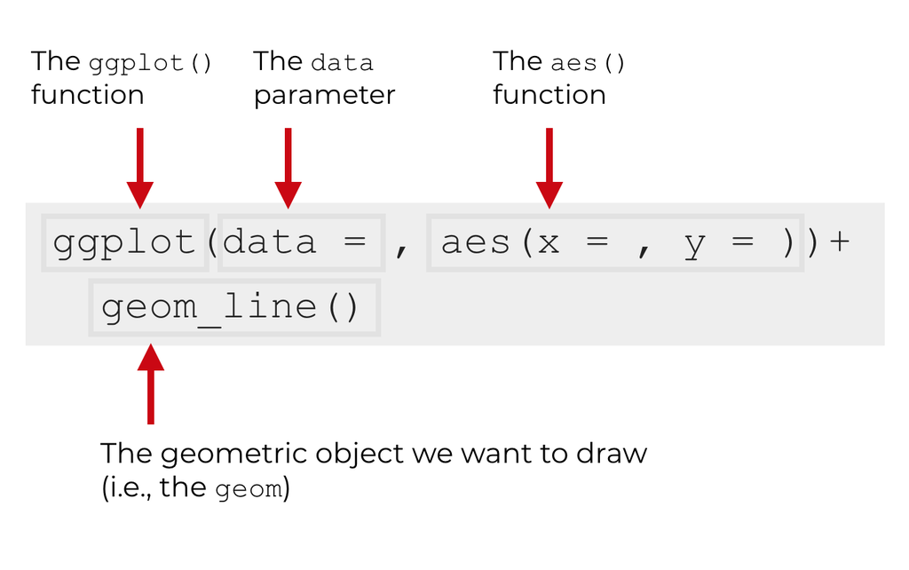

## Texas Housing Example

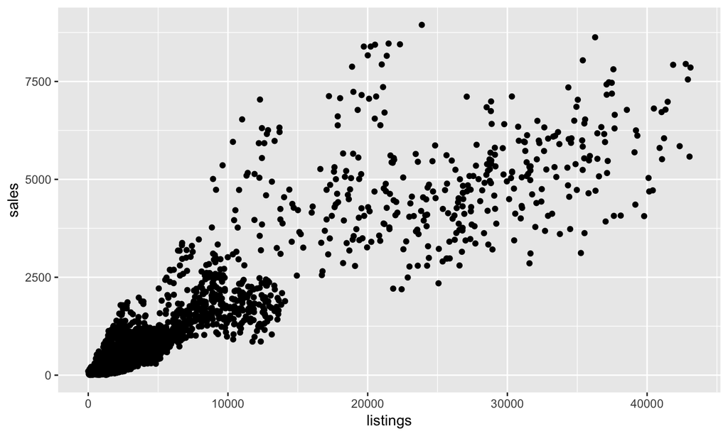

```r
ggplot(data = txhousing, aes(x = listings, y = sales)) +
  geom_point()
```

## Break it down

We start with data.

```r
ggplot(data = txhousing, _____) +
  _____
```

## Break it down

We map columns from the data to `x` and `y` in `aes()`

```r
ggplot(data = txhousing, aes(x = listings, y = sales)) +
  _____
```

## Break it down

We tell R how to display the data (i.e. as points.)

```r
ggplot(data = txhousing, aes(x = listings, y = sales)) +
  geom_point()
```

## Adding an aesthetic

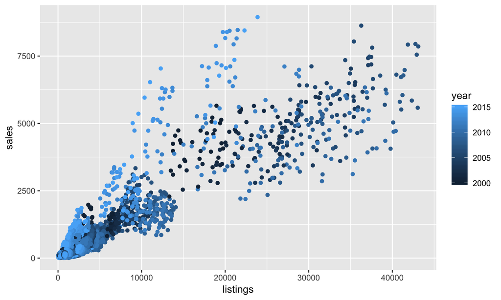

```r
txhousing %>%
  ggplot(aes(x = listings, y = sales, color = year)) +
  geom_point()
```

For more resources, checkout [chapter 3 of R for Data Science](https://r4ds.had.co.nz/data-visualisation.html)

## Recap

Today we:

- Reviewed vectorization
- Introduced for loops
- Discussed best practices for loops
- Went over the basics of ggplot2

Next week: writing functions

Find the workshop link on the course web page: http://harris-coding-lab.github.io